# Verdissement

## PMD (Administration Coderre):

Planter 300 000 arbres d’ici 2050. Ajouter 1 000 hectares d’espaces protégés. Doubler le nombre de toits verts sur les bâtiments municipaux. «Verdir» les règlements municipaux. Entamer un projet de recherche sur la phytoremédiation couvrant quatre hectares afin de réduire la toxicité des sols, en négociant avec les autres niveaux de gouvernement pour obtenir des fonds. Encourager les organisations partenaires à contribuer aux projets de verdissement. Encourager les organisations partenaires à lutter contre les espèces envahissantes et à prévenir leur introduction. Ajouter quatre hectares de parcs et autres espaces publics au projet de campus de l’Université de Montréal.

## Plan climat (Administration Plante):

Planter, préserver et protéger 500 000 arbres, en priorisant les zones vulnérables aux vagues de chaleur, financés à 50 % par le budget d’investissement décennal (l’autre moitié du financement n’est pas spécifié). Augmenter la superficie des aires protégées de 6,1 % à 10 %. Restaurer de plusieurs berges. Resserrer la réglementation sur les pesticides tout en envisageant d’autres méthodes de contrôle. Soutenir le verdissement et le jardinage communautaire en tant que partie intégrante des pôles de résilience, ce qui permettra de développer le capital social local.

## Discussion

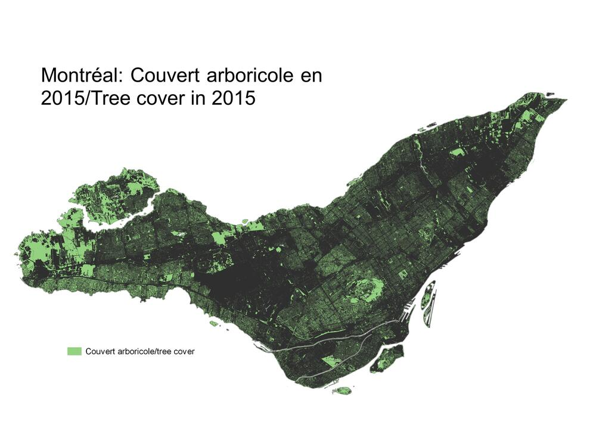

Les programmes de verdissement des deux plans sont simples et presque identiques. Ils visent à rendre la ville plus verte de la manière la plus simple possible : plus d’arbres, davantage d’espaces protégés pour les parcs et les forêts, et l’implication de la communauté dans des projets locaux pour ajouter de la verdure dans leurs quartiers. Bien qu’il n’y ait pas eu de progrès en ce qui concerne l’extension de la superficie des terres protégées (au cours des cinq années séparant les plans, l’objectif de protéger 10% de la superficie de l’île n’a pas changé), certains projets sont en cours de réalisation, comme le Grand parc de l’Ouest. Un suivi plus approfondi des changements dans les espaces verts et la canopée pourrait aider à déterminer comment la plantation d’arbres et la croissance des espaces verts ont été distribuées, car aucun plan ne spécifie exactement où la plantation d’arbres et l’expansion des espaces verts auront lieu, bien que le Plan climat fasse allusion au ciblage des zones vulnérables à la chaleur pour la plantation d’arbres.